# Biostat 203B Homework 5

Due Mar 22 @ 11:59PM

Author

Brilla Meng, UID:806329681

## Predicting ICU duration

Using the ICU cohort `mimiciv_icu_cohort.rds` you built in Homework 4, develop at least three machine learning approaches (logistic regression with enet regularization, random forest, boosting, SVM, MLP, etc) plus a model stacking approach for predicting whether a patient’s ICU stay will be longer than 2 days. You should use the `los_long` variable as the outcome. You algorithms can use patient demographic information (gender, age at ICU `intime`, marital status, race), ICU admission information (first care unit), the last lab measurements before the ICU stay, and first vital measurements during ICU stay as features. You are welcome to use any feature engineering techniques you think are appropriate; but make sure to not use features that are not available at an ICU stay’s `intime`. For instance, `last_careunit` cannot be used in your algorithms.

1. Data preprocessing and feature engineering.

```r
library(GGally)
library(gtsummary)
library(dplyr)
library(tidymodels)
library(tidyverse)
library(ranger)
```

```r
mimic_icu_cohort <- readRDS("mimic_icu_cohort.rds")
```

```r
mimic_icu_cohort <- mimic_icu_cohort %>%
  select(-c(
    last_careunit,
    intime,
    outtime,
    los,
    deathtime,
    admittime,
    dischtime,
    discharge_location,
    dod,
    anchor_year_group,
    edregtime,
    edouttime,
    age_intime,
    admit_provider_id
  )) %>%
mutate(los_long = as.factor(los_long),
       gender = as.factor(gender),
       insurance = as.factor(insurance),
       language = as.factor(language),
       marital_status = as.factor(marital_status)
       )
```

2. Partition data into 50% training set and 50% test set. Stratify partitioning according to `los_long`. For grading purpose, sort the data by `subject_id`, `hadm_id`, and `stay_id` and use the seed `203` for the initial data split. Below is the sample code.

```r
set.seed(203)

# sort
mimiciv_icu_cohort <- mimic_icu_cohort |>
  arrange(subject_id, hadm_id, stay_id) |>
  select(-subject_id, -hadm_id, -stay_id)

data_split <- initial_split(
  mimiciv_icu_cohort,
  # stratify by los_long
  strata = "los_long",
  prop = 0.5
)
mimic_other <- training(data_split)
mimic_test <- testing(data_split)
dim(mimic_other)
```

```
[1] 36590    25
```

```r
dim(mimic_test)
```

```
[1] 36591    25
```

3. Train and tune the models using the training set.

#Lasso

```r
norm_recipe <-
  recipe(
    los_long ~ .,
    data = mimic_other
  ) %>%
  # create traditional dummy variables
  step_impute_mean(all_numeric(),-all_outcomes()) %>%
  step_impute_mode(all_nominal(),-all_outcomes()) %>%
  step_dummy(all_nominal(),-all_outcomes()) %>%
  # zero-variance filter
  step_zv(all_numeric_predictors()) %>%
  step_normalize(all_numeric_predictors())
  # center and scale numeric data
  # step_log(Salary, base = 10) %>%
  # estimate the means and standard deviations
norm_recipe
```

```
── Recipe ──────────────────────────────────────────────────────────────────────
```

```
── Inputs
```

```
Number of variables by role
```

```
outcome:    1
predictor: 24
```

```
── Operations
```

```
• Mean imputation for: all_numeric() and -all_outcomes()
```

```
• Mode imputation for: all_nominal() and -all_outcomes()
```

```
• Dummy variables from: all_nominal() and -all_outcomes()
```

```
• Zero variance filter on: all_numeric_predictors()
```

```
• Centering and scaling for: all_numeric_predictors()
```

```r
logit_mod <-
  logistic_reg(penalty = tune(), mixture = tune()
               ) %>%
  set_engine("glmnet", standardize = FALSE) %>%
  print()
```

```
Logistic Regression Model Specification (classification)

Main Arguments:
  penalty = tune()
  mixture = tune()

Engine-Specific Arguments:
  standardize = FALSE

Computational engine: glmnet
```

```r
logit_workflow <-
  workflow() %>%
  add_recipe(norm_recipe) %>%
  add_model(logit_mod)
logit_workflow
```

```
══ Workflow ════════════════════════════════════════════════════════════════════
Preprocessor: Recipe
Model: logistic_reg()

── Preprocessor ────────────────────────────────────────────────────────────────
5 Recipe Steps

• step_impute_mean()
• step_impute_mode()
• step_dummy()
• step_zv()
• step_normalize()

── Model ───────────────────────────────────────────────────────────────────────
Logistic Regression Model Specification (classification)

Main Arguments:
  penalty = tune()
  mixture = tune()

Engine-Specific Arguments:
  standardize = FALSE

Computational engine: glmnet
```

```r
param_grid <- grid_regular(
  penalty(
    range = c(-6, 3)),
  mixture(),
  levels = c(100,5)
) %>%
  print()
```

```
# A tibble: 500 × 2
      penalty mixture
        <dbl>   <dbl>
 1 0.000001         0
 2 0.00000123       0
 3 0.00000152       0
 4 0.00000187       0
 5 0.00000231       0
 6 0.00000285       0
 7 0.00000351       0
 8 0.00000433       0
 9 0.00000534       0
10 0.00000658       0
# ℹ 490 more rows
```

```r
set.seed(203)

folds <- vfold_cv(mimic_other, v = 5)
folds
```

```
#  5-fold cross-validation
# A tibble: 5 × 2
  splits               id
  <list>               <chr>
1 <split [29272/7318]> Fold1
2 <split [29272/7318]> Fold2
3 <split [29272/7318]> Fold3
4 <split [29272/7318]> Fold4
5 <split [29272/7318]> Fold5
```

```r
logit_fit <-
  logit_workflow %>%
  tune_grid(
    resamples = folds,
    grid = param_grid,
    metrics = metric_set(roc_auc, accuracy)
  )
logit_fit
```

```
# Tuning results
# 5-fold cross-validation
# A tibble: 5 × 4
  splits               id    .metrics             .notes
  <list>               <chr> <list>               <list>
1 <split [29272/7318]> Fold1 <tibble [1,000 × 6]> <tibble [0 × 3]>
2 <split [29272/7318]> Fold2 <tibble [1,000 × 6]> <tibble [0 × 3]>
3 <split [29272/7318]> Fold3 <tibble [1,000 × 6]> <tibble [0 × 3]>
4 <split [29272/7318]> Fold4 <tibble [1,000 × 6]> <tibble [0 × 3]>
5 <split [29272/7318]> Fold5 <tibble [1,000 × 6]> <tibble [0 × 3]>
```

```
# A tibble: 1,000 × 8
      penalty mixture .metric  .estimator  mean     n std_err
        <dbl>   <dbl> <chr>    <chr>      <dbl> <int>   <dbl>
 1 0.000001         0 accuracy binary     0.581     5 0.00141
 2 0.000001         0 roc_auc  binary     0.615     5 0.00246
 3 0.00000123       0 accuracy binary     0.581     5 0.00141
 4 0.00000123       0 roc_auc  binary     0.615     5 0.00246
 5 0.00000152       0 accuracy binary     0.581     5 0.00141
 6 0.00000152       0 roc_auc  binary     0.615     5 0.00246
 7 0.00000187       0 accuracy binary     0.581     5 0.00141
 8 0.00000187       0 roc_auc  binary     0.615     5 0.00246
 9 0.00000231       0 accuracy binary     0.581     5 0.00141
10 0.00000231       0 roc_auc  binary     0.615     5 0.00246
   .config
   <chr>
 1 Preprocessor1_Model001
 2 Preprocessor1_Model001
 3 Preprocessor1_Model002
 4 Preprocessor1_Model002
 5 Preprocessor1_Model003
 6 Preprocessor1_Model003
 7 Preprocessor1_Model004
 8 Preprocessor1_Model004
 9 Preprocessor1_Model005
10 Preprocessor1_Model005
# ℹ 990 more rows
```

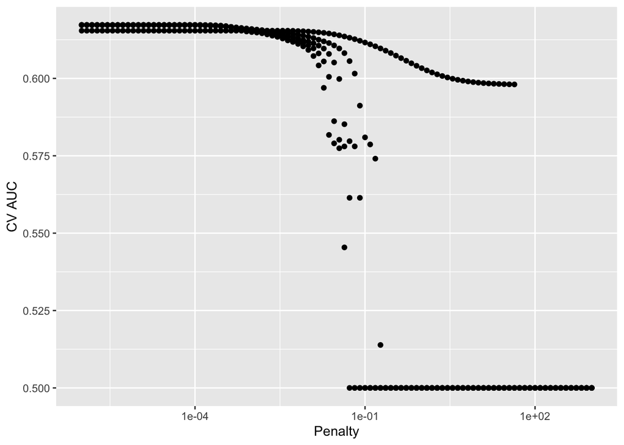

```r
logit_fit %>%
  collect_metrics() %>%
  print(width = Inf) %>%
  filter(.metric == "roc_auc") %>%
  ggplot(mapping = aes(x = penalty, y = mean)) +
  geom_point() +
  labs(x = "Penalty", y = "CV AUC") +
  scale_x_log10()
```

```r
logit_fit %>%
  show_best("roc_auc")
```

```
# A tibble: 5 × 8
     penalty mixture .metric .estimator  mean     n std_err .config
       <dbl>   <dbl> <chr>   <chr>      <dbl> <int>   <dbl> <chr>
1 0.000001         1 roc_auc binary     0.617     5 0.00207 Preprocessor1_Model…
2 0.00000123       1 roc_auc binary     0.617     5 0.00207 Preprocessor1_Model…
3 0.00000152       1 roc_auc binary     0.617     5 0.00207 Preprocessor1_Model…
4 0.00000187       1 roc_auc binary     0.617     5 0.00207 Preprocessor1_Model…
5 0.00000231       1 roc_auc binary     0.617     5 0.00207 Preprocessor1_Model…
```

```r
best_logit <-logit_fit %>%
  select_best("roc_auc")
best_logit
```

```
# A tibble: 1 × 3
   penalty mixture .config
     <dbl>   <dbl> <chr>
1 0.000001       1 Preprocessor1_Model401
```

```r
final_wf <- logit_workflow %>%
  finalize_workflow(best_logit)
final_wf
```

```
══ Workflow ════════════════════════════════════════════════════════════════════
Preprocessor: Recipe
Model: logistic_reg()

── Preprocessor ────────────────────────────────────────────────────────────────
5 Recipe Steps

• step_impute_mean()
• step_impute_mode()
• step_dummy()
• step_zv()
• step_normalize()

── Model ───────────────────────────────────────────────────────────────────────
Logistic Regression Model Specification (classification)

Main Arguments:
  penalty = 1e-06
  mixture = 1

Engine-Specific Arguments:
  standardize = FALSE

Computational engine: glmnet
```

```r
final_fit <-
  final_wf %>%
  last_fit(data_split)
final_fit
```

```
# Resampling results
# Manual resampling
# A tibble: 1 × 6
  splits                id             .metrics .notes   .predictions .workflow
  <list>                <chr>          <list>   <list>   <list>       <list>
1 <split [36590/36591]> train/test sp… <tibble> <tibble> <tibble>     <workflow>
```

```r
final_fit %>%
  collect_metrics()
```

```
# A tibble: 2 × 4
  .metric  .estimator .estimate .config
  <chr>    <chr>          <dbl> <chr>
1 accuracy binary         0.577 Preprocessor1_Model1
2 roc_auc  binary         0.608 Preprocessor1_Model1
```

```r
final_tree <- extract_workflow(final_fit)
final_tree
```

```
══ Workflow [trained] ══════════════════════════════════════════════════════════
Preprocessor: Recipe
Model: logistic_reg()

── Preprocessor ────────────────────────────────────────────────────────────────
5 Recipe Steps

• step_impute_mean()
• step_impute_mode()
• step_dummy()
• step_zv()
• step_normalize()

── Model ───────────────────────────────────────────────────────────────────────

```

[output cut: 52 more lines]

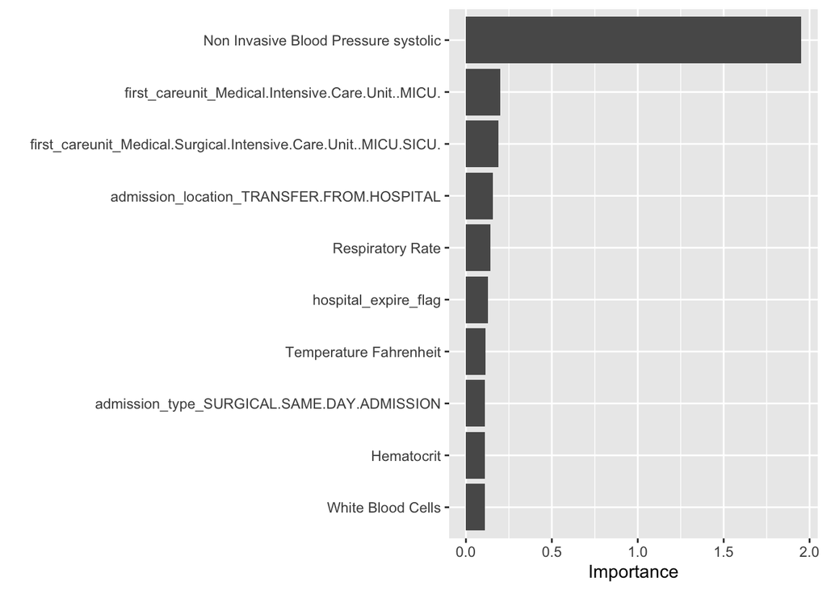

```r
library(vip)
final_tree %>%
 extract_fit_parsnip() %>%
  vip()
```

# Random Forest

```r
rf_mod <-
  rand_forest(
    mode = "classification",
    mtry = tune(),
    trees = tune()
  ) %>%
  set_engine("ranger")
```

```r
rf_workflow <-
  workflow() %>%
  add_recipe(norm_recipe) %>%
  add_model(rf_mod)
```

```r
param_grid <- grid_regular(
  trees(range = c(100L, 300L)),
  mtry(range = c(1L, 5L)),
  levels = c(5,5)
  )
param_grid
```

```
# A tibble: 25 × 2
   trees  mtry
   <int> <int>
 1   100     1
 2   150     1
 3   200     1
 4   250     1
 5   300     1
 6   100     2
 7   150     2
 8   200     2
 9   250     2
10   300     2
# ℹ 15 more rows
```

```r
rf_fit <-
  rf_workflow %>%
  tune_grid(
    resamples = folds,
    grid = param_grid,
    metrics = metric_set(roc_auc, accuracy)
  )
rf_fit
```

```
# Tuning results
# 5-fold cross-validation
# A tibble: 5 × 4
  splits               id    .metrics          .notes
  <list>               <chr> <list>            <list>
1 <split [29272/7318]> Fold1 <tibble [50 × 6]> <tibble [0 × 3]>
2 <split [29272/7318]> Fold2 <tibble [50 × 6]> <tibble [0 × 3]>
3 <split [29272/7318]> Fold3 <tibble [50 × 6]> <tibble [0 × 3]>
4 <split [29272/7318]> Fold4 <tibble [50 × 6]> <tibble [0 × 3]>
5 <split [29272/7318]> Fold5 <tibble [50 × 6]> <tibble [0 × 3]>
```

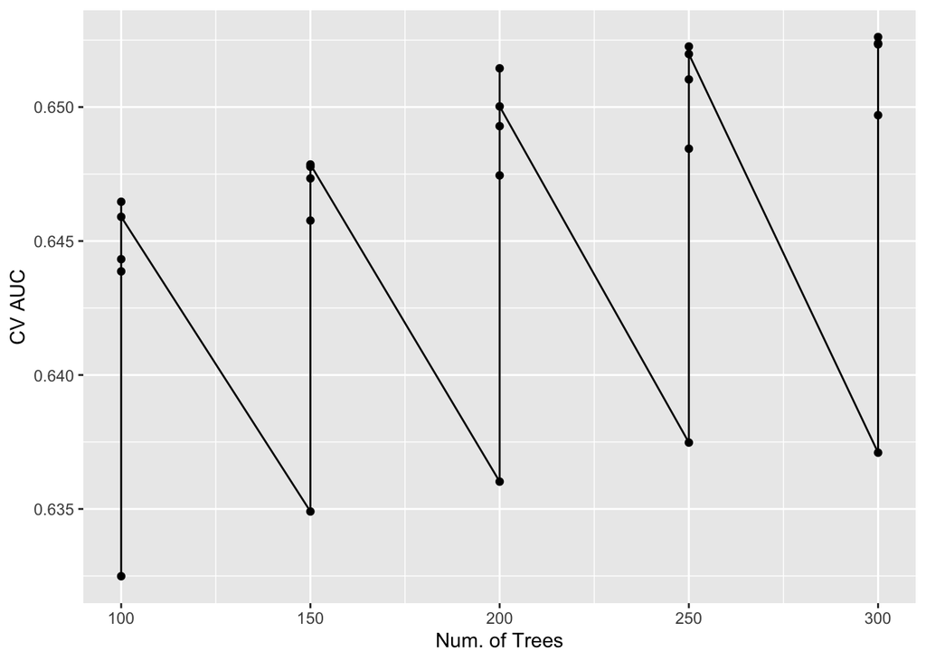

```r
rf_fit %>%
  collect_metrics() %>%
  filter(.metric == "roc_auc") %>%
  ggplot(mapping = aes(x = trees, y = mean)) +
  geom_point() +
  geom_line() +
  labs(x = "Num. of Trees", y = "CV AUC")
```

```r
rf_fit %>%
  show_best("roc_auc")
```

```
# A tibble: 5 × 8
   mtry trees .metric .estimator  mean     n std_err .config
  <int> <int> <chr>   <chr>      <dbl> <int>   <dbl> <chr>
1     4   300 roc_auc binary     0.653     5 0.00273 Preprocessor1_Model20
2     3   300 roc_auc binary     0.652     5 0.00202 Preprocessor1_Model15
3     5   300 roc_auc binary     0.652     5 0.00252 Preprocessor1_Model25
4     4   250 roc_auc binary     0.652     5 0.00239 Preprocessor1_Model19
5     5   250 roc_auc binary     0.652     5 0.00280 Preprocessor1_Model24
```

```r
best_rf <- rf_fit %>%
  select_best("roc_auc")
best_rf
```

```
# A tibble: 1 × 3
   mtry trees .config
  <int> <int> <chr>
1     4   300 Preprocessor1_Model20
```

```r
final_wf <- rf_workflow %>%
  finalize_workflow(best_rf)
final_wf
```

```
══ Workflow ════════════════════════════════════════════════════════════════════
Preprocessor: Recipe
Model: rand_forest()

── Preprocessor ────────────────────────────────────────────────────────────────
5 Recipe Steps

• step_impute_mean()
• step_impute_mode()
• step_dummy()
• step_zv()
• step_normalize()

── Model ───────────────────────────────────────────────────────────────────────
Random Forest Model Specification (classification)

Main Arguments:
  mtry = 4
  trees = 300

Computational engine: ranger
```

```r
final_fit <-
  final_wf %>%
  last_fit(data_split)
final_fit
```

```
# Resampling results
# Manual resampling
# A tibble: 1 × 6
  splits                id             .metrics .notes   .predictions .workflow
  <list>                <chr>          <list>   <list>   <list>       <list>
1 <split [36590/36591]> train/test sp… <tibble> <tibble> <tibble>     <workflow>
```

```r
final_fit %>%
  collect_metrics()
```

```
# A tibble: 2 × 4
  .metric  .estimator .estimate .config
  <chr>    <chr>          <dbl> <chr>
1 accuracy binary         0.609 Preprocessor1_Model1
2 roc_auc  binary         0.651 Preprocessor1_Model1
```